# Grupo 2:

Leticia Trein, Patriky Galvão, Guilherme Nascimento

2024-06-11

# Exercício em Grupo: Análise de dados de emissão de CO2 de veículos no Canadá

Chamando pacotes necessários

```r
require(dplyr)
require(stats)
require(car)
```

```r
require(ggplot2)
```

Buscando dados

```r
dados <- read.csv("C:/Users/chii/Documents/POS_ESPECIALIZACAO/Estatistica/Aula 8 - pratica/CO2 Emissions_Canada.csv")
```

Adaptando nomes das colunas

```r
dados <- dados %>%
    dplyr::rename(CO2.Emissions = CO2.Emissions.g.km.) %>%
    dplyr::rename(Combustivel_rodovia = Fuel.Consumption.Hwy..L.100.km.)
```

# Exercicio 1: Primeiro passo: descreva/contextualize o conjunto de dados

## Análise Exploratória

#### A base de dados contém as seguintes informações:

**Make** = marca do carro  
**Model** = modelo do carro  
**Vehicle Class** = classificação do veículo de acordo com sua utilidade, capacidade e peso  
**Engine Size L** = tamanho do motor, em litros (refere-se a capacidade cúbica do motor)  
**Cylinders** = número de cilindros  
**Transmission** = tipo de transmissão com número de marchas  
**Fuel Type** = tipo de combustível utilizado  
**Fuel Consumption City L 100km** = consumo de combustível na cidade (L/100 km)  
**Fuel Consumption Hwy L 100km** = consumo de combustível na rodovia (L/100 km)  
**Fuel Consumption Comb. L 100km** = consumo combinado de combustível (55% cidade, 45% rodovia), em L/100 km  
**Fuel Consumption Comb. mpg** = consumo combinado de combustível (55% cidade, 45% rodovia), em milhas por galão  
**CO2 Emissions g/km*** = Emissões de CO2 pelo escapamento (em gramas/Km) para condução combinada (cidade e rodovia)

```r
summary(dados)
```

```
##      Make              Model           Vehicle.Class      Engine.Size.L.
##  Length:7385        Length:7385        Length:7385        Min.   :0.90
##  Class :character   Class :character   Class :character   1st Qu.:2.00
##  Mode  :character   Mode  :character   Mode  :character   Median :3.00
##                                                           Mean   :3.16
##                                                           3rd Qu.:3.70
##                                                           Max.   :8.40
##    Cylinders      Transmission        Fuel.Type
##  Min.   : 3.000   Length:7385        Length:7385
##  1st Qu.: 4.000   Class :character   Class :character
##  Median : 6.000   Mode  :character   Mode  :character
##  Mean   : 5.615
##  3rd Qu.: 6.000
##  Max.   :16.000
##  Fuel.Consumption.City..L.100.km. Combustivel_rodovia
##  Min.   : 4.20                    Min.   : 4.000
##  1st Qu.:10.10                    1st Qu.: 7.500
##  Median :12.10                    Median : 8.700
##  Mean   :12.56                    Mean   : 9.042
##  3rd Qu.:14.60                    3rd Qu.:10.200
##  Max.   :30.60                    Max.   :20.600
##  Fuel.Consumption.Comb..L.100.km. Fuel.Consumption.Comb..mpg. CO2.Emissions
##  Min.   : 4.10                    Min.   :11.00               Min.   : 96.0
##  1st Qu.: 8.90                    1st Qu.:22.00               1st Qu.:208.0
##  Median :10.60                    Median :27.00               Median :246.0
##  Mean   :10.98                    Mean   :27.48               Mean   :250.6
##  3rd Qu.:12.60                    3rd Qu.:32.00               3rd Qu.:288.0
##  Max.   :26.10                    Max.   :69.00               Max.   :522.0
```

### Sobre as variáveis:

**CATEGÓRICAS**: Make, Model, Vehicle Class, Transmission, Fuel Type  
**QUANTITATIVAS**: Engine Size L, Cylinders, Fuel Consumption City L 100km, Fuel Consumption Hwy L 100km, Fuel Consumption Comb. L 100km, Fuel Consumption Comb. mpg, CO2 Emissions g/km.

#### Sobre as variáveis categóricas:

**Make** = Possui 42 marcas de carros.

```r
# Distribuição das Marcas
length(unique(dados$Make))
```

```
## [1] 42
```

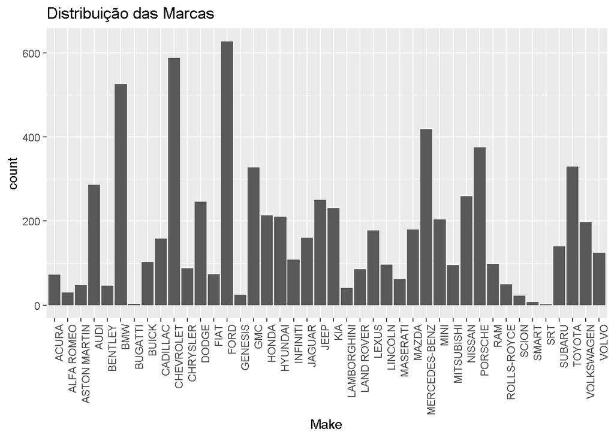

```r
ggplot(dados, aes(x = Make)) +
  geom_bar() +
  theme(axis.text.x = element_text(angle = 90, hjust = 1)) +
  labs(title = "Distribuição das Marcas")
```

**Model** = Possui 2053 modelos de carros.

```r
length(unique(dados$Model))
```

```
## [1] 2053
```

**Vehicle Class** = Possui 16 classificações de veículos.

```r
# Distribuição das Classes de Veículos
length(unique(dados$Vehicle.Class))
```

```
## [1] 16
```

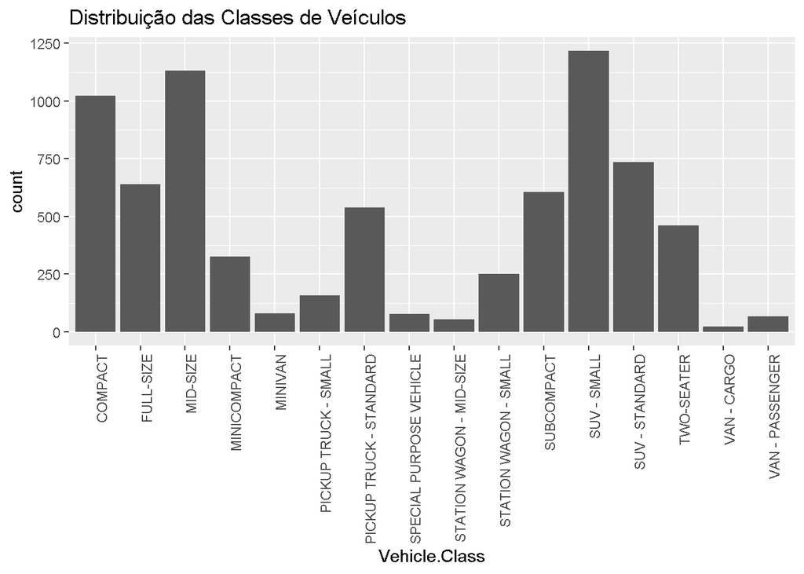

```r
ggplot(dados, aes(x = Vehicle.Class)) +
  geom_bar() +
  theme(axis.text.x = element_text(angle = 90, hjust = 1)) +
  labs(title = "Distribuição das Classes de Veículos")
```

**Transmission** = Possui 27 tipos de transmissão.

```r
# Distribuição dos Tipos de Transmissão
length(unique(dados$Transmission))
```

```
## [1] 27
```

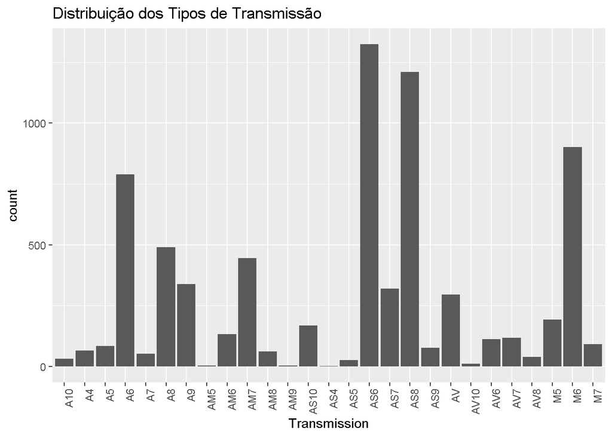

```r
ggplot(dados, aes(x = Transmission)) +
  geom_bar() +
  theme(axis.text.x = element_text(angle = 90, hjust = 1)) +
  labs(title = "Distribuição dos Tipos de Transmissão")
```

**Fuel Type** = Possui 5 tipos de combustível.

```r
# Distribuição dos Tipos de Combustível
length(unique(dados$Fuel.Type))
```

```
## [1] 5
```

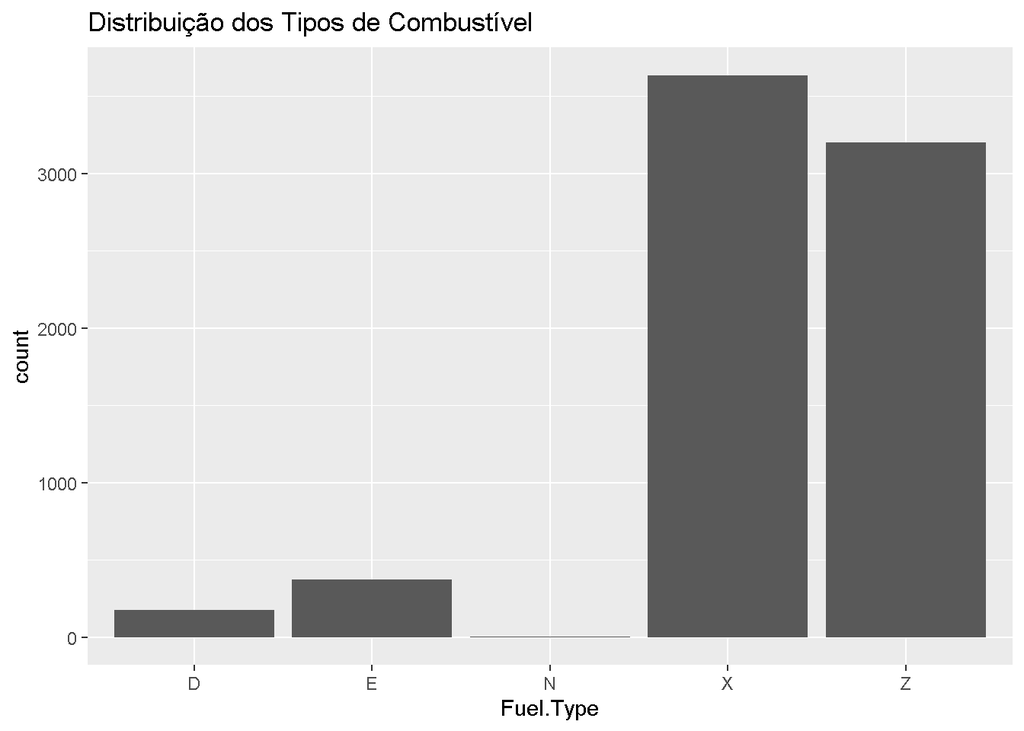

```r
ggplot(dados, aes(x = Fuel.Type)) +
  geom_bar() +
  labs(title = "Distribuição dos Tipos de Combustível")
```

#### Sobre as variáveis quantitativas:

**Engine Size L** = Possui valor mínimo de 0.9, máximo de 8,4. O primeiro quartil apresenta valor 2,0, a mediana de 3,0, média de 3,16 e terceiro quartil de 3,7.

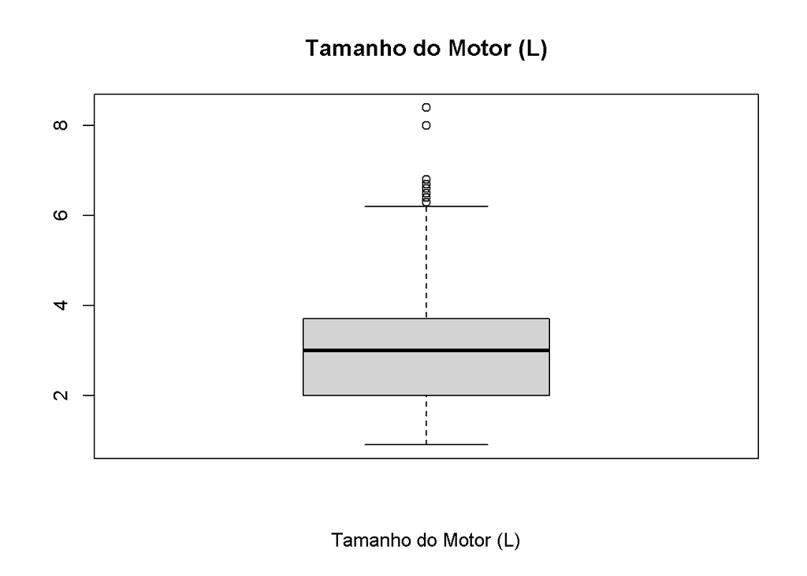

```r
boxplot(dados$Engine.Size.L, main = "Tamanho do Motor (L)", xlab = "Tamanho do Motor (L)")
```

**Cylinders** = Possui valor mínimo de 3, máximo de 16. O primeiro quartil apresenta valor 4, a mediana de 6, média de 5,6 e terceiro quartil de 6.

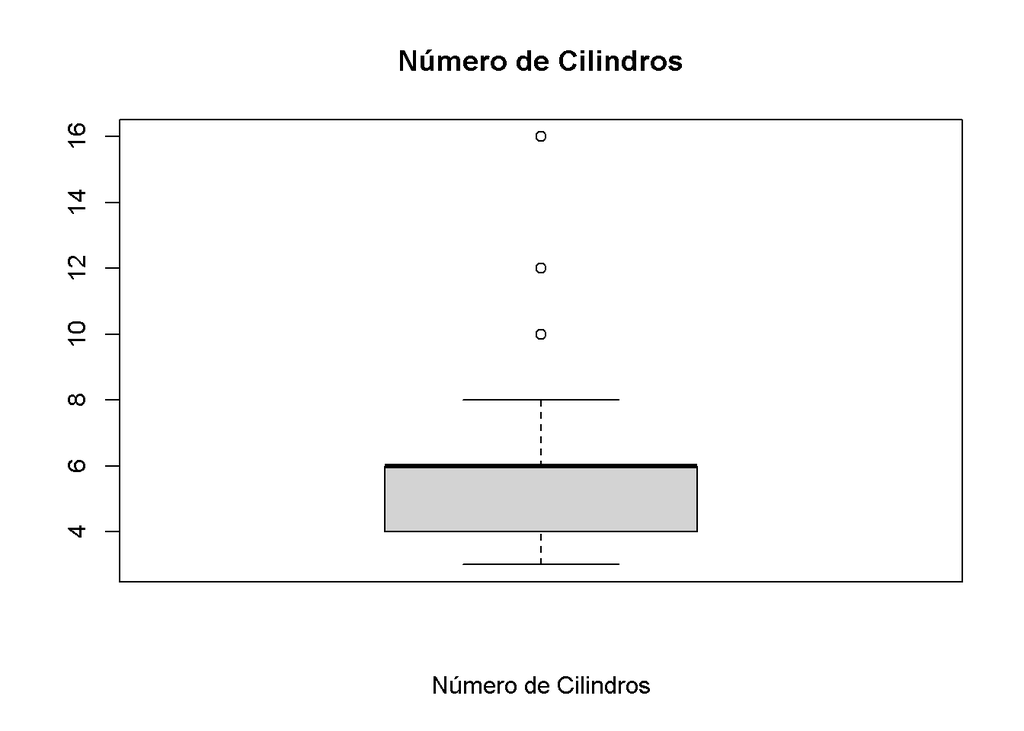

```r
boxplot(dados$Cylinders, main = "Número de Cilindros", xlab = "Número de Cilindros")
```

**Fuel Consumption City L 100km** = Possui valor mínimo de 4,2, máximo de 30,6. O primeiro quartil apresenta valor 10,1, a mediana de 12,1, média de 12,56 e terceiro quartil de 14,6.

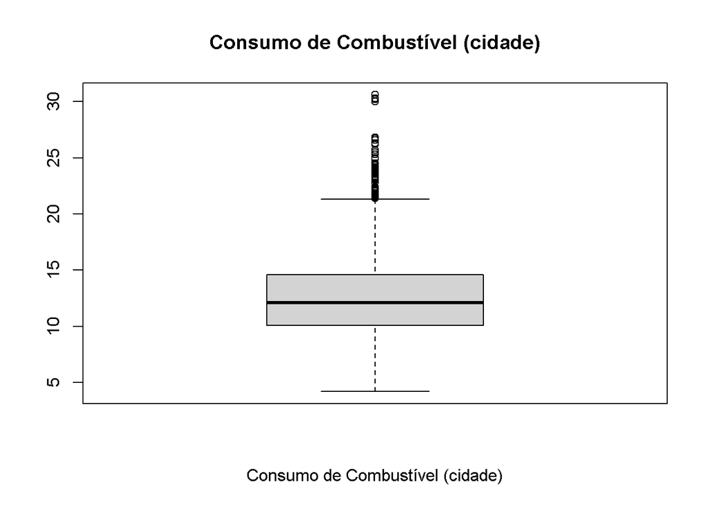

```r
boxplot(dados$Fuel.Consumption.City..L.100.km., main = "Consumo de Combustível (cidade)", xlab = "Consumo de Combustível (cidade)")
```

**Fuel Consumption Hwy L 100km** = Possui valor mínimo de 4,0, máximo de 20,6. O primeiro quartil apresenta valor 7,5, a mediana de 8,7, média de 9,042 e terceiro quartil de 10,2.

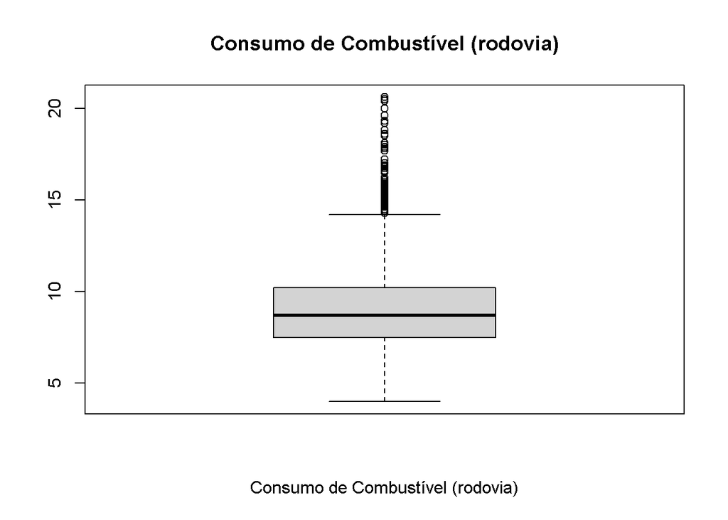

```r
boxplot(dados$Combustivel_rodovia, main = "Consumo de Combustível (rodovia)", xlab = "Consumo de Combustível (rodovia)")
```

**Fuel Consumption Comb. L 100km** = Possui valor mínimo de 4,1, máximo de 26,1. O primeiro quartil apresenta valor 8,9, a mediana de 10,6, média de 10.98 e terceiro quartil de 12,6.

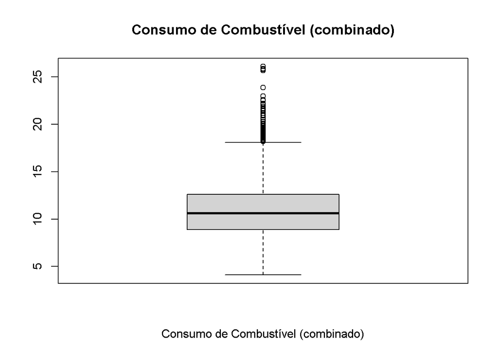

```r
boxplot(dados$Fuel.Consumption.Comb..L.100.km., main = "Consumo de Combustível (combinado)", xlab = "Consumo de Combustível (combinado)")
```

**Fuel Consumption Comb. mpg** = Possui valor mínimo de 11,0, máximo de 69. O primeiro quartil apresenta valor 22,0, a mediana de 27, média de 27,48 e terceiro quartil de 32,0.

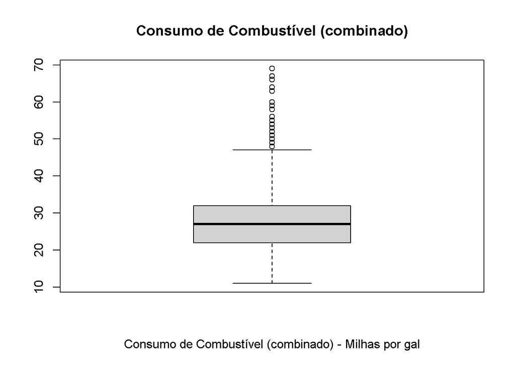

```r
boxplot(dados$Fuel.Consumption.Comb..mpg., main = "Consumo de Combustível (combinado)", xlab = "Consumo de Combustível (combinado) - Milhas por gal")
```

**CO2 Emissions g/km** = Possui valor mínimo de 96, máximo de 522,0. O primeiro quartil apresenta valor 208, a mediana de 246, média de 250,6 e terceiro quartil de 288,0.

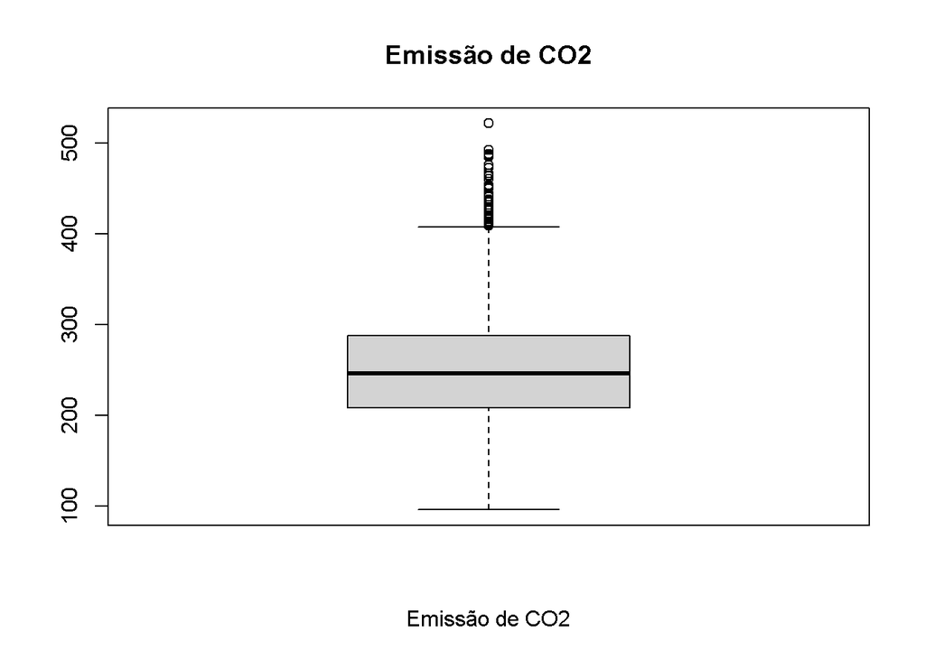

```r
boxplot(dados$CO2.Emissions, main = "Emissão de CO2", xlab = "Emissão de CO2")
```

.

.

# Exercicio 2: Existe diferença na proporção de carros automáticos entre as marcas FORD e CHEVROLET?

Gerando Coluna para Exercicio 2: Carros Ford e Chevrolet com transmissão manual

```r
dados_exercio2 <-  dados %>%
dplyr::filter(Make %in% c('FORD', 'CHEVROLET')) %>%
dplyr::mutate(manual = factor(dplyr::case_when(Transmission %in% c('M5', 'M6', 'M7') ~ 'Sim',TRUE ~ 'Não'), levels = c('Sim', 'Não')))
```

Avaliando a proporção de carros Ford e Chevrolet com transmissão manual

```r
table(dados_exercio2$Make, dados_exercio2$manual)
```

```
##
##             Sim Não
##   CHEVROLET 100 488
##   FORD       74 554
```

```r
round(prop.table(table(dados_exercio2$Make, dados_exercio2$manual), 1)*100,1)
```

```
##
##              Sim  Não
##   CHEVROLET 17.0 83.0
##   FORD      11.8 88.2
```

```r
#Avaliando a diferença de proporção de carros com transmissão manual entre Ford e Chevrolet
prop.test(table(dados_exercio2$Make, dados_exercio2$manual))
```

```
##
##  2-sample test for equality of proportions with continuity correction
##
## data:  table(dados_exercio2$Make, dados_exercio2$manual)
## X-squared = 6.3377, df = 1, p-value = 0.01182
## alternative hypothesis: two.sided
## 95 percent confidence interval:
##  0.01111600 0.09335126
## sample estimates:
##    prop 1    prop 2
## 0.1700680 0.1178344
```

### Resposta: Como o resultado é inferior à 0.05, rejeitamos a hipótese nula de que as proporções são iguais. Portanto, a proporção de carros com transmissão manual é diferente entre Ford e Chevrolet.

# Exercicio 3: Existe correlação entre consumo de combustível (rodovia) e emissão de CO2 considerando os veículos do tipo COMPACT?

```r
#Selecionando dados de veículos do tipo COMPACT:
dados_exercio3 <-  dados %>%
dplyr::filter(Vehicle.Class %in% c('COMPACT'))
```

Avaliando variáveis de interesse em relação a sua distribuição normal

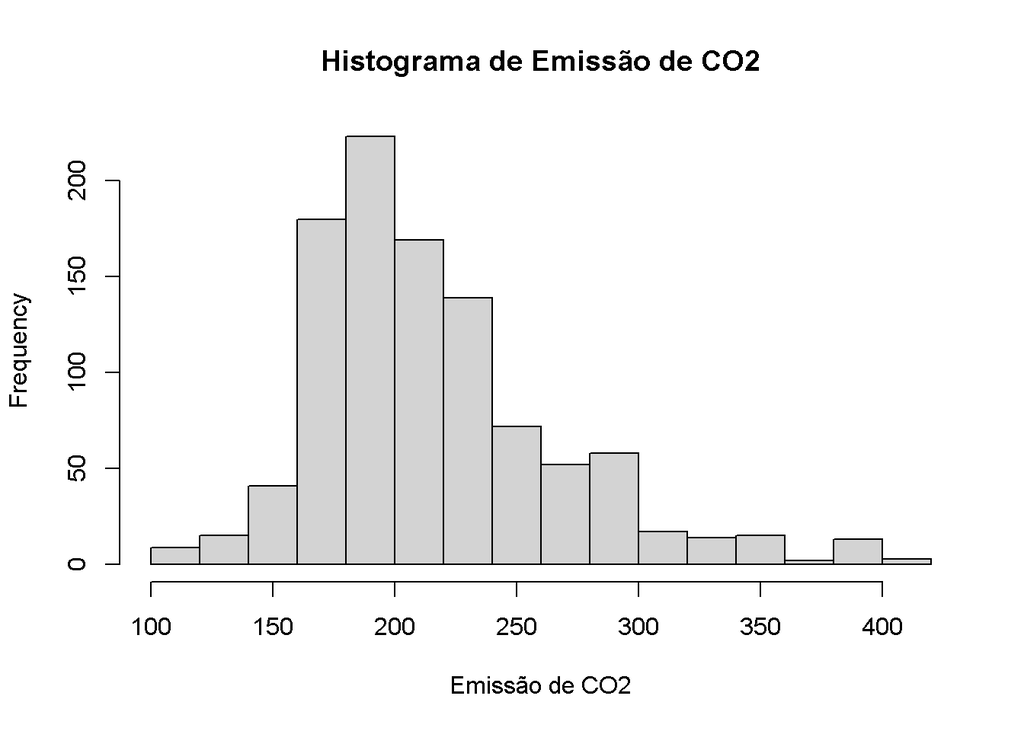

```r
hist(dados_exercio3$CO2.Emissions, main = "Histograma de Emissão de CO2", xlab = "Emissão de CO2")
```

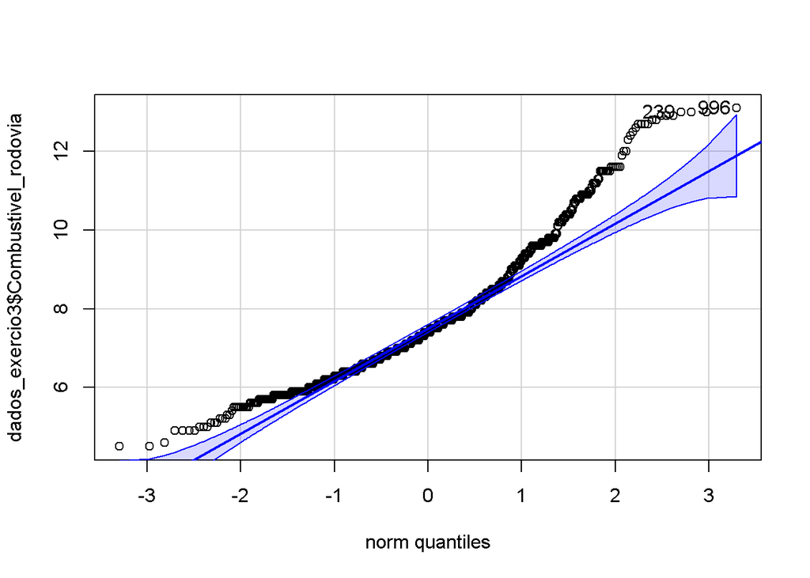

```
## [1] 996 239
```

```r
car::qqPlot(dados_exercio3$Combustivel_rodovia)
```

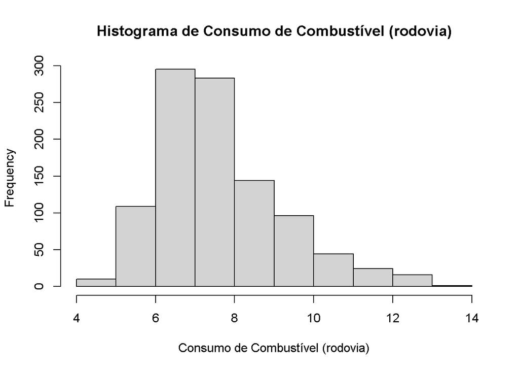

```r
## Não atende a normalidade

hist(dados_exercio3$Combustivel_rodovia, main = "Histograma de Consumo de Combustível (rodovia)", xlab = "Consumo de Combustível (rodovia)")
```

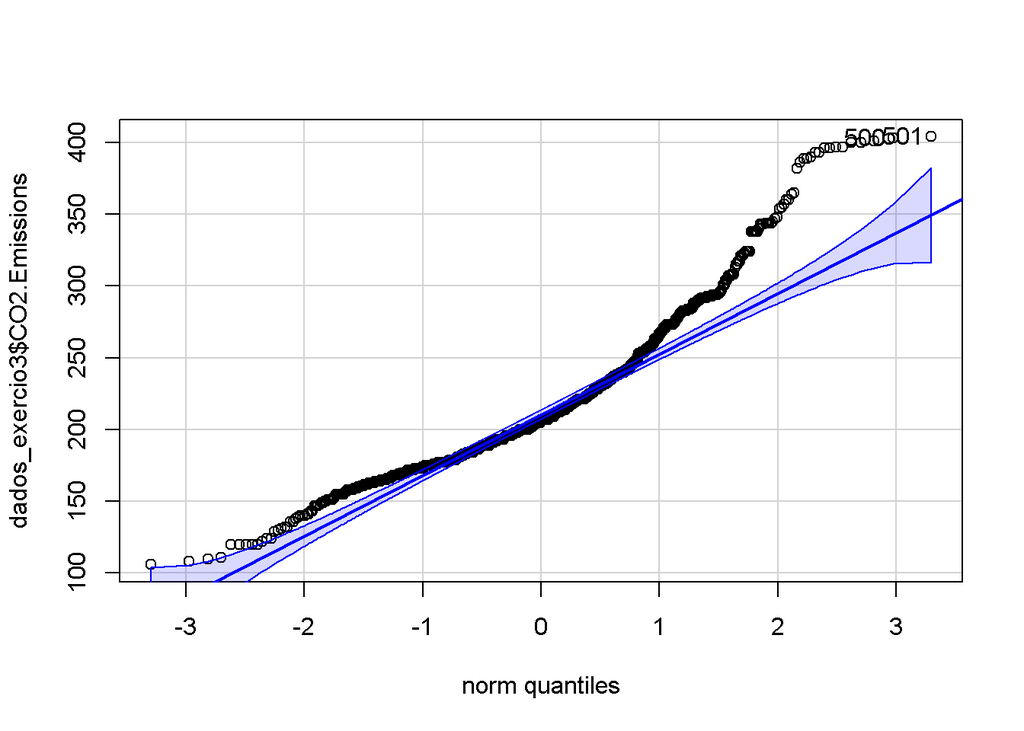

```
## [1] 501 500
```

```r
car::qqPlot(dados_exercio3$CO2.Emissions)
```

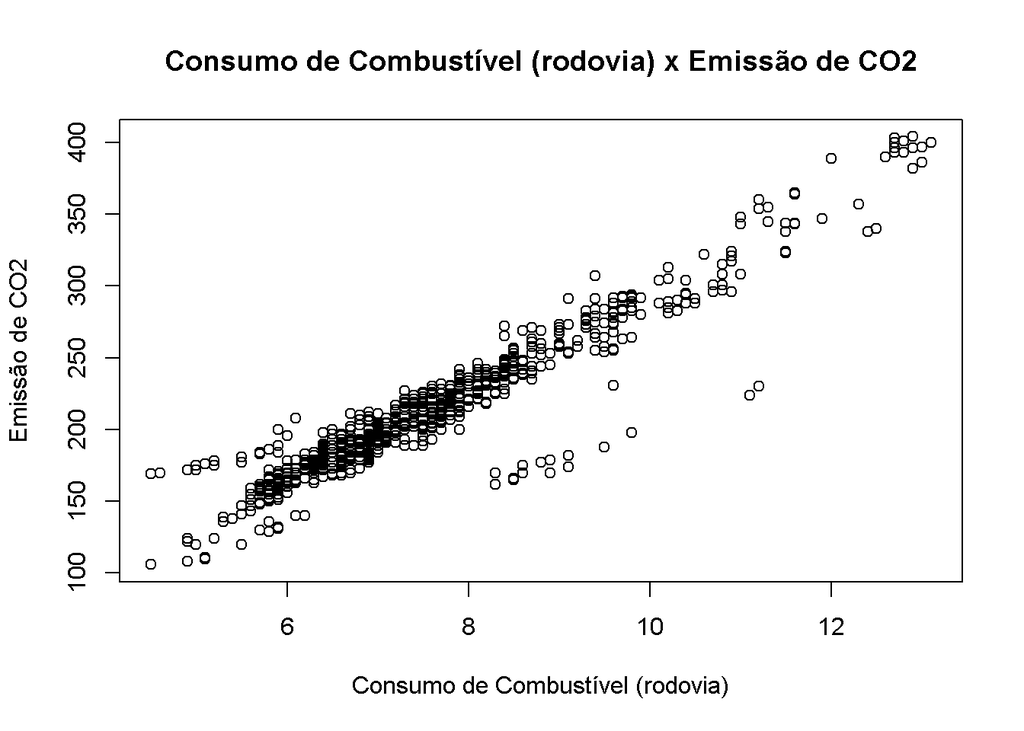

```r
## Não atende a normalidade

plot(dados_exercio3$Combustivel_rodovia, dados_exercio3$CO2.Emissions, main = "Consumo de Combustível (rodovia) x Emissão de CO2", xlab = "Consumo de Combustível (rodovia)", ylab = "Emissão de CO2")
```

```r
cor(dados_exercio3$Combustivel_rodovia, dados_exercio3$CO2.Emissions, method = "spearman")
```

```
## [1] 0.9330428
```

```r
cor.test(dados_exercio3$Combustivel_rodovia, dados_exercio3$CO2.Emissions, method = "spearman")
```

```
##
##  Spearman's rank correlation rho
##
## data:  dados_exercio3$Combustivel_rodovia and dados_exercio3$CO2.Emissions
## S = 11912369, p-value < 2.2e-16
## alternative hypothesis: true rho is not equal to 0
## sample estimates:
##       rho
## 0.9330428
```

### Resposta:A Correlação é significativa, tendo um valor de 0,93, sendo forte. Vemos uma relação linear positiva entre as variáveis, ou seja, quanto maior o consumo de combustível, maior a emissão de CO2.

# Exercicio 4: Existe diferença na quantidade média de emissão de CO2 nas SUV-Small das marcas KIA, SUBARU e TOYOTA?

Selecionando dados de veículos do tipo SUV-Small das marcas KIA, SUBARU e TOYOTA:

```r
dados_exercio4 <- dados %>%
dplyr::filter(Vehicle.Class == 'SUV - SMALL' & Make %in% c('KIA', 'SUBARU', 'TOYOTA'))
```

Avaliando variáveis de interesse em relação a sua distribuição normal

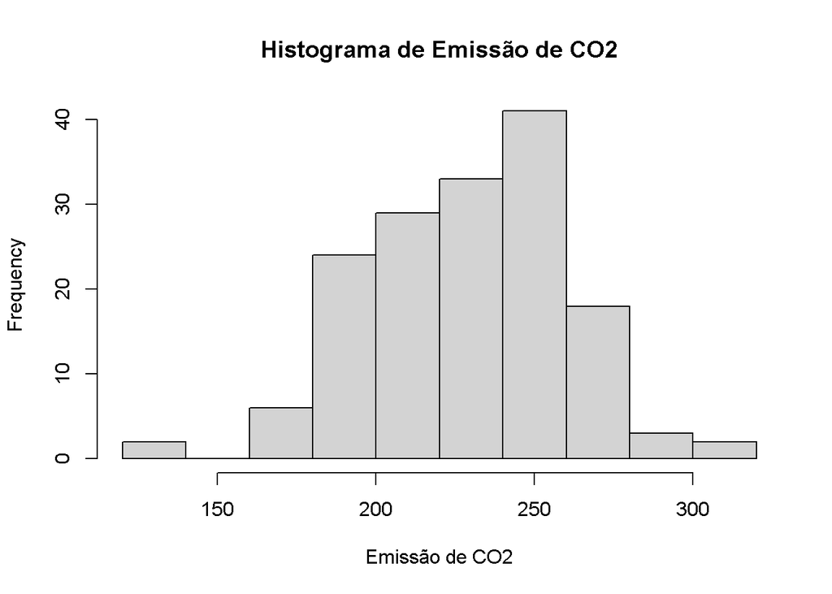

```r
hist(dados_exercio4$CO2.Emissions, main = "Histograma de Emissão de CO2", xlab = "Emissão de CO2")
```

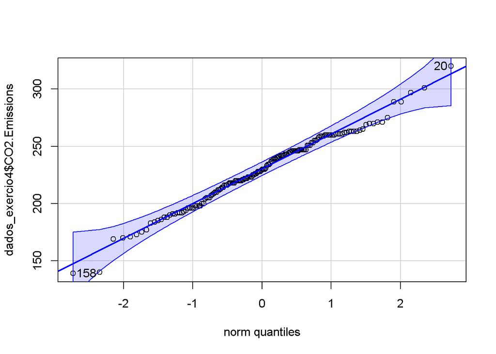

```
## [1]  20 158
```

```r
car::qqPlot(dados_exercio4$CO2.Emissions)  ## aceita normalidade
```

Avaliando a diferença na quantidade média de emissão de CO2 nas SUV-Small das marcas KIA, SUBARU e TOYOTA

```r
aov_test <- aov(CO2.Emissions ~ Make, data = dados_exercio4)
summary(aov_test)
```

```
##              Df Sum Sq Mean Sq F value   Pr(>F)
## Make          2  40331   20165    29.8 1.12e-11 ***
## Residuals   155 104892     677
## ---
## Signif. codes:  0 '***' 0.001 '**' 0.01 '*' 0.05 '.' 0.1 ' ' 1
```

```r
TukeyHSD(aov_test)
```

```
##   Tukey multiple comparisons of means
##     95% family-wise confidence level
##
## Fit: aov(formula = CO2.Emissions ~ Make, data = dados_exercio4)
##
## $Make
##                    diff          lwr       upr     p adj
## SUBARU-KIA    -38.15094 -50.10950121 -26.19239 0.0000000
## TOYOTA-KIA    -26.17816 -38.19407008 -14.16224 0.0000023
## TOYOTA-SUBARU  11.97279  -0.04312668  23.98870 0.0510538
```

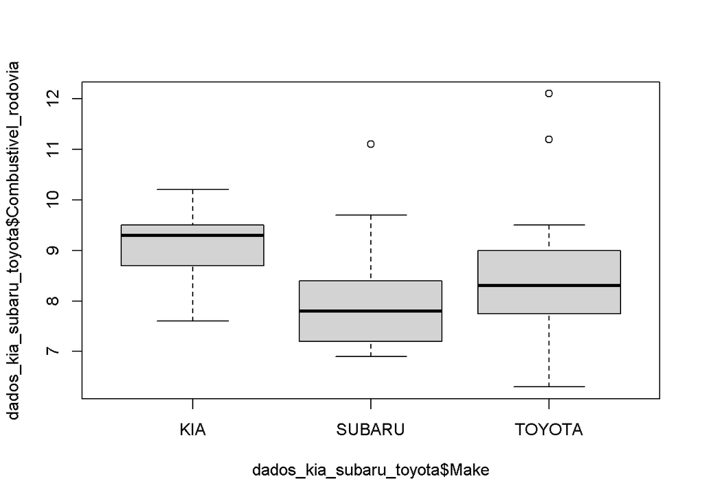

```r
# Plot de visualização
dados_kia_subaru_toyota <- dados %>% dplyr::filter(Vehicle.Class == 'SUV - SMALL' & Make %in% c('KIA','SUBARU','TOYOTA'))
boxplot(dados_kia_subaru_toyota$Combustivel_rodovia ~ dados_kia_subaru_toyota$Make)
```

Avaliando distribuição da emissão de CO2 por marca escolhida

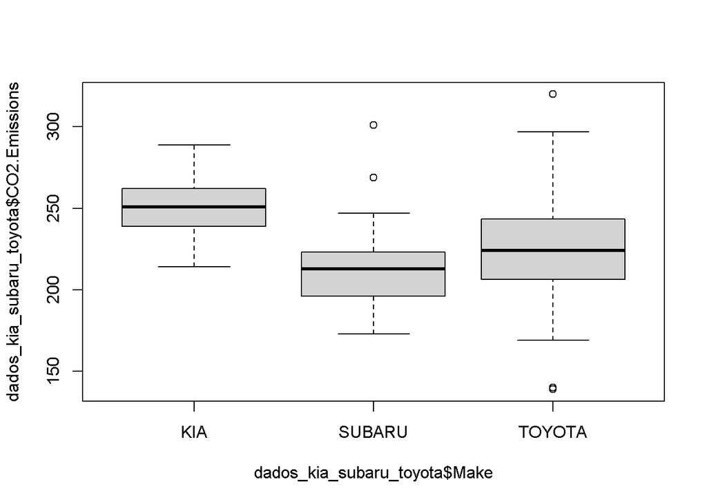

```r
boxplot(dados_kia_subaru_toyota$CO2.Emissions ~ dados_kia_subaru_toyota$Make)
```